# ¿Quiénes confían en los medios de comunicación en las Américas

REPLICACIÓN DEL INSIGHTS 142

SOBRE LA BASE DE DATOS

Pueden descargar los datos de manera libre en: http://datasets.americasbarometer.org/database/login.php

En este enlace, se puede registrar o entrar como “Free User”. En el buscador, se puede ingresar el texto “merge”. Ahí se tendrá acceso a la base de datos completa “2004-2018 Grand Merge Free” en versión para STATA. Se descarga la base de datos en formato zip, la que se descomprime en formato .dta.

INSTALANDO LAS LIBRERÍAS NECESARIAS EN R

```r
library(foreign)
library(descr)
library(DescTools)
library(haven)
library(tidyverse)
library(ggplot2)
library(gplots)
library(dplyr)
library(psych)
library(Rmisc)
library(vcd)
library(psych)
library(car)
library(dummies)
library(jtools)
library(huxtable)
library(broom.mixed)
```

LEYENDO LA BASE DE DATOS EN R

Se carga la base de datos en STATA en R en un dataframe “lapopmerge”. Tenga en cuenta que la base de datos tiene que estar en su directorio de trabajo (working directory). Para este Insights se analiza la ronda 2016/17, por lo que se selecciona esta ronda en el merge total. Se crea un nuevo dataframe “lapop”. Luego, también se elimina las observaciones de los países que no se analizan en este reporte por no tener datos de la variable sobre medios de comunicación. Se elimina el dataframe del Merge original. Finalmente el dataframe “lapop” incluye solo la ronda 2016/17 y los países de análisis.

```r
lapopmerge <- read_dta("LAPOP_Merge_2004_2018.dta")
lapop <- subset(lapopmerge, year==2016 | year==2017)
lapop <- subset(lapop, pais<=23 | pais>=40)
rm(lapopmerge)
```

Pueden conseguir el texto en: https://www.vanderbilt.edu/lapop/insights/IO942es.pdf

GRÁFICO 1

```r
lapop$b37r <- recode(lapop$b37, "1:4=0 ; 5:7=100")
table(lapop$b37r)
```

```
    0   100
17487 17568
```

Al momento de leer la base de datos en R, este programa importa las variables como numéricas. La variable “pais” se tiene que convertir en una variable de tipo “factor” y se tiene que etiquetar.

```r
lapop$pais = as.factor(lapop$pais)
levels(lapop$pais) <- c("México", "Guatemala", "El Salvador", "Honduras",
                            "Nicaragua","Costa Rica", "Panamá", "Colombia",
                            "Ecuador", "Bolivia", "Perú", "Paraguay", "Chile",
                            "Uruguay", "Brasil", "Venezuela", "Argentina",
                            "Rep. Dom.", "Haití", "Jamaica", "Estados Unidos",
                            "Canada")
levels(lapop$pais)
```

```
 [1] "México"         "Guatemala"      "El Salvador"    "Honduras"
 [5] "Nicaragua"      "Costa Rica"     "Panamá"         "Colombia"
 [9] "Ecuador"        "Bolivia"        "Perú"           "Paraguay"
[13] "Chile"          "Uruguay"        "Brasil"         "Venezuela"
[17] "Argentina"      "Rep. Dom."      "Haití"          "Jamaica"
[21] "Estados Unidos" "Canada"
```

```r
table(lapop$pais)
```

```
        México      Guatemala    El Salvador       Honduras      Nicaragua
          1563           1546           1551           1560           1560
    Costa Rica         Panamá       Colombia        Ecuador        Bolivia
          1514           1521           1563           1545           1691
          Perú       Paraguay          Chile        Uruguay         Brasil
          2647           1528           1625           1514           1532
     Venezuela      Argentina      Rep. Dom.          Haití        Jamaica
          1558           1528           1518           2221           1515
Estados Unidos         Canada
          1500           1511
```

Luego, se calculan los datos de % e intervalos de confianza de la variable b37r por cada país y se guarda en un objeto “df”

```r
df <- summarySE(data=lapop, measurevar="b37r", groupvar="pais", na.rm=T)
```

Con estos datos, se construye el gráfico 1 con el siguiente código. Tenemos que tomar en cuenta que en algunos países los % no son similares porque este código no incluye las ponderaciones muestrales.

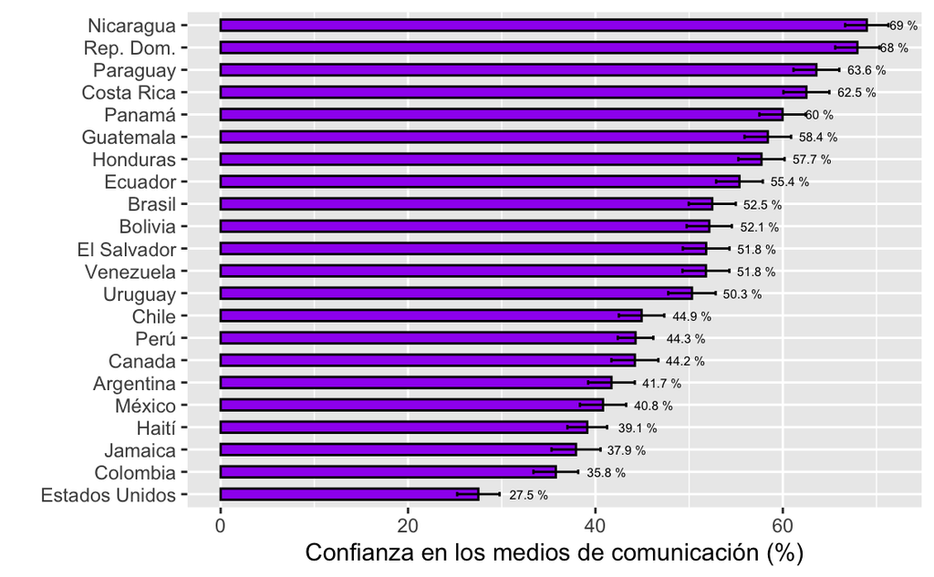

```r
graf1 <- ggplot(df, aes(x=reorder(pais, b37r), y=b37r)) +
  geom_bar(width=0.5, fill="purple", colour="black", stat="identity") +
  geom_errorbar(aes(ymin=b37r-ci, ymax=b37r+ci), width= 0.2) +
  geom_text(aes(label=paste(round(b37r, 1), "%")), hjust=-0.8, size=2) +
  xlab("") +
  ylab("Confianza en los medios de comunicación (%)")  +
  coord_flip()
graf1
```

FACTORES SOCIODEMOGRÁFICOS Y CONFIANZA EN LOS MEDIOS DE COMUNICACIÓN

Para evaluar la confianza en los medios de comunicación, se comienza evaluando los efectos del género, la educación y el tamaño del lugar de residencia. Se espera que la mujer va a tender a reportar más confianza en los medios de comunicación que los hombres, pues investigaciones anteriores han encontrado que, en promedio, las mujeres confían más. Estos mayores niveles de confianza debieran también observarse en la confianza en los medios de comunicación. Por otro lado, se espera que las personas con niveles más altos de educación formal tendrán menos probabilidad de confiar en los medios de comunicación porque están mejor equipados para ser consumidores críticos de los medios de comunicación. Se espera que las personas que viven en las ciudades de mayor tamaño van a confiar menos en los medios de comunicación que quienes viven en las poblaciones más pequeñas porque los residentes de las grandes ciudades tienen, en promedio, más probabilidad de contar con un mayor número de medios, los cuales pueden ofrecer información contradictoria y en consecuencia reducir la confianza. Esta expectativa coincide con los hallazgos de anteriores reportes de Perspectivas, que analizaron la ronda 2010 del Barómetro de las Américas. Mientras que la percepción pública de los medios de comunicación pudo haber experimentado algunos cambios durante el periodo entre 2010-2016/17, se espera que tales resultados sean en general consistentes. También se controla por la edad, tono de piel y nivel de riqueza en el modelo, como predictores sociodemográficos/socioeconómicos típicos. El Gráfico 2 presenta los efectos estimados para estas seis características demográficas y socioeconómicas en la confianza reportada en los medios de comunicación, como estimados de un modelo de regresión de mínimos cuadrados ordinarios.

GRÁFICO 2

Para repreducir el segundo gráfico se tiene que recodificar las variables independientes para que varíen entre 0 y 1.

```r
lapop$edrr <- lapop$edr/3
lapop$size <- (5-lapop$tamano)/4
lapop$edadr <- (lapop$edad -1)/5
lapop$tono <- (lapop$colorr-1)/10
lapop$nse <- (lapop$quintall-1)/4
```

Luego de recodificar las variables, se tiene que correr el modelo usando como variable dependiente b37 y las variables recodificadas como variables independientes. Adicionalmente, se incluye variables dummy por país, aunque no se mostrarán en el gráfico.

```r
modelo1 <- lm(b37 ~ mujer + edrr + size +
                edadr + tono + nse + factor(pais), data=lapop)
modelo1
```

```
Call:
lm(formula = b37 ~ mujer + edrr + size + edadr + tono + nse +
    factor(pais), data = lapop)

Coefficients:
            (Intercept)                    mujer                     edrr
                4.51820                  0.15415                 -0.72806
                   size                    edadr                     tono
               -0.24113                  0.03064                  0.14514
                    nse    factor(pais)Guatemala  factor(pais)El Salvador
               -0.22123                  0.66163                  0.42859
   factor(pais)Honduras    factor(pais)Nicaragua   factor(pais)Costa Rica
                0.60082                  1.11442                  0.84298
     factor(pais)Panamá     factor(pais)Colombia      factor(pais)Ecuador
                0.79306                 -0.14550                  0.76405
    factor(pais)Bolivia         factor(pais)Perú     factor(pais)Paraguay
                0.60910                  0.29943                  0.87518
      factor(pais)Chile      factor(pais)Uruguay       factor(pais)Brasil
                0.29028                  0.49261                  0.51616
  factor(pais)Venezuela    factor(pais)Argentina    factor(pais)Rep. Dom.
                0.60503                  0.08392                  1.08648
      factor(pais)Haití      factor(pais)Jamaica
               -0.21293                 -0.05912
```

Para visualizar mejor los resultados, podemos usar el siguiente código:

```r
export_summs(modelo1)
```

```
            ───────────────────────────────────────────────────
                                                      Model 1
                                      ─────────────────────────
              (Intercept)                            4.52 ***
                                                    (0.06)
              mujer                                  0.15 ***
                                                    (0.02)
              edrr                                  -0.73 ***
                                                    (0.05)
              size                                  -0.24 ***
                                                    (0.03)
              edadr                                  0.03
                                                    (0.03)
              tono                                   0.15 *
                                                    (0.07)
              nse                                   -0.22 ***
                                                    (0.03)
              factor(pais)Guatemala                  0.66 ***
                                                    (0.07)
              factor(pais)El Salvador                0.43 ***
                                                    (0.07)
              factor(pais)Honduras                   0.60 ***
                                                    (0.07)
              factor(pais)Nicaragua                  1.11 ***
                                                    (0.07)
              factor(pais)Costa Rica                 0.84 ***
                                                    (0.07)
              factor(pais)Panamá                     0.79 ***
                                                    (0.07)
              factor(pais)Colombia                  -0.15 *
                                                    (0.07)
              factor(pais)Ecuador                    0.76 ***
                                                    (0.07)
              factor(pais)Bolivia                    0.61 ***
                                                    (0.06)
              factor(pais)Perú                       0.30 ***
                                                    (0.06)
              factor(pais)Paraguay                   0.88 ***
                                                    (0.07)
              factor(pais)Chile                      0.29 ***
                                                    (0.06)
              factor(pais)Uruguay                    0.49 ***
                                                    (0.07)
              factor(pais)Brasil                     0.52 ***
                                                    (0.07)
              factor(pais)Venezuela                  0.61 ***
                                                    (0.07)
              factor(pais)Argentina                  0.08
                                                    (0.07)
              factor(pais)Rep. Dom.                  1.09 ***
                                                    (0.07)
              factor(pais)Haití                     -0.21 **
                                                    (0.07)
              factor(pais)Jamaica                   -0.06
                                                    (0.07)
                                      ─────────────────────────
              N                                  30918
              R2                                     0.07
            ───────────────────────────────────────────────────
              *** p < 0.001; ** p < 0.01; * p < 0.05.

Column names: names, Model 1
```

Para reproducir el gráfico 2, podemos usar el siguiente código:

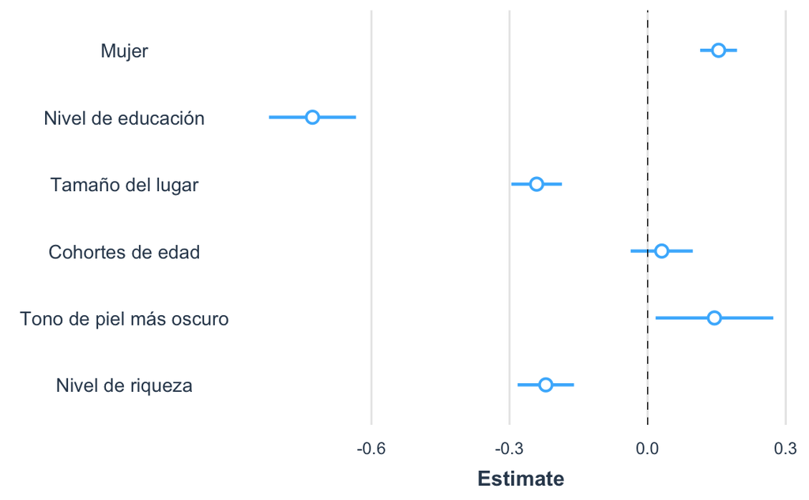

```r
plot_summs(modelo1, coefs=c("Mujer" = "mujer", "Nivel de educación" = "edrr",
                            "Tamaño del lugar" = "size",
                            "Cohortes de edad" = "edadr",
                            "Tono de piel más oscuro" = "tono",
                            "Nivel de riqueza" = "nse"))
```

EXPLICACIONES ADICIONALES DE LA CONFIANZA EN LOS MEDIOS DE COMUNICACIÓN

Investigadores han propuesto una amplia variedad de explicaciones para la variación en la confianza en los medios de comunicación a nivel individual. En este reporte, se consideran explicaciones que se concentran en tres tipos de factores: disposición a confiar, el consumo de medios y, el involucramiento y comportamiento político de cada persona. Primero se considera la posibilidad de que algunas personas tengan, en promedio, una mayor disposición a confiar que otros. Si, independientemente del objeto en cuestión, algunas personas confían más que otras, entonces esta característica podría influir en el nivel reportado de confianza en los medios de comunicación. Como una medida aproximada de la inclinación de una persona a confiar, se incluye la confianza interpersonal y la asistencia a la iglesia. La confianza interpersonal se refiere a la medida en la que una persona reporta que, en general, se puede confiar en las personas. Adicionalmente, algunos investigadores han encontrado que la asistencia a la iglesia esta relacionada con una mayor disposición a confiar. En línea con las investigaciones anteriores, se espera que un mayor nivel de confianza interpersonal y la asistencia reportada a los servicios religiosos predecirán un mayor nivel de confianza en los medios de comunicación. Segundo, se considera que la confianza de las personas en los medios de comunicación puede estar relacionada con sus niveles de consumo de medios. Dado que la relación de una persona con los medios masivos generalmente está definida por su nivel de consumo, la frecuencia y el medio usado para acceder a los medios puede que influyan en su opinión de qué tan confiables son los medios de comunicación y lo que piensan mientras responden a una pregunta en una encuesta sobre los medios. Recientemente, la posibilidad de una relación entre el consume de noticias y la confianza en los medios de comunicación ha recibido un nivel de atención considerable19. Debido a la expectativa de que las personas que no confían en los medios de comunicación van a preferir consumir fuentes alternativas de información 20, un mayor consumo de noticias debiera predecir un mayor nivel de confianza en los medios de comunicación. Aún más, algunos investigadores reportan hallazgos que sugieren que la relación entre la confianza en los medios y el consumo de noticias varía dependiendo del medio que se consume21. En particular, investigaciones recientes han cuestionado la posibilidad de que exista una única relación entre la confianza en los medios de comunicación y el consumo de noticias en línea. Los investigadores han encontrado de forma consistente una relación positiva entre la confianza en los medios de comunicación y el consumo de noticias a través de la televisión o en medios impresos. La asociación entre el consumo de noticias en línea y la confianza en los medios de comunicación, sin embargo, permanece sin precisar, dado que los investigadores han llegado a resultados contradictorios24. Como una exploración indirecta de los posibles efectos del consumo de noticias en línea en la confianza en los medios de comunicación, se incluye la frecuencia reportada con que usan Internet como variable independiente. Aunque esta medida es una aproximación al consumo de medios a través de Internet, se espera que las personas que usan Internet con más frecuencia tengan una mayor probabilidad de estar expuestos a noticias en línea. Tercero, se considera la forma como la orientación y el involucramiento de las personas en política puede estar asociado a su confianza en los medios de comunicación. Aunque el involucramiento en política puede tomar muchas formas, nos enfocamos en el interés de las personas en la política, la identificación con un partido político, la evaluación de cómo está funcionando la democracia, y el reporte de cómo votaron en las elecciones presidenciales más recientes como factores que podrían influir en la confianza en los medios de una persona. Se espera que las personas que están más interesadas en la política van, en promedio, a confiar menos en los medios de comunicación que las personas que no están tan interesadas en política. Las personas que están más interesadas en política podrían tener más opiniones políticas que las personas menos interesadas, lo cual significa que tienen una mayor probabilidad de encontrarse con contenido en los medios que rete o ponga en duda sus creencias. Adicionalmente, las personas que estánmás interesadas en política pueden considerar que existen más temas con implicaciones, llevándolos a rechazar información en los medios de comunicación con más frecuencia. En comparación, se espera que las personas que se identifican con un partido político, en promedio, van a confiar en los medios menos que las personas que no se identifican con un partido político. La afiliación a un partido político y la identificación partidista 28 han sido identificadas como predictores de que se perciba un mayor sesgo en los medios de comunicación en contra del partido político de cada persona. En promedio, los miembros de un partido también pueden considerar que un mayor número de temas son relevantes a nivel personal que los independientes, y tales personas tienen una mayor probabilidad de rechazar información relacionada con los temas que ellos esperan que los afecten. También se considera la forma como la opinión de las personas sobre el sistema político de su país puede afectar su nivel de confianza en los medios de comunicación. Investigaciones anteriores han encontrado una relación positiva entre la confianza política y la confianza en los medios de comunicación. En particular, algunos investigadores han sugerido que la confianza política podría estar asociada con la confianza en los medios porque ambas están afectadas por el nivel de confianza del público en las instituciones sociales31. Para dar cuenta de la confianza política, se incluye la satisfacción de las personas con la forma como funciona la democracia en su país. Coincidiendo con hallazgos anteriores, se espera que las personas que reportan un mayor nivel de satisfacción con la democracia existente en su país también reporten un mayor nivel de confianza en los medios de comunicación. Por último, se examina cómo el voto en las más recientes elecciones presidenciales podría estar relacionado con el nivel reportado de confianza en los medios de comunicación. Aunque existen resultados variados sobre cómo un mayor nivel de involucramiento en política puede influir en la confianza en los medios, se espera que los más recientes “ganadores” o políticos o las personas que votaron por el más reciente ganador de las elecciones presidenciales van a confiar más en los medios que los más recientes “perdedores” políticos. Dado que “ganadores” más recientes tienden a exhibir un mayor nivel de confianza en el gobierno y las instituciones políticas que los “perdedores”, esta expectativa representa una extensión natural de la relación positiva entre confianza política y confianza en los medios de comunicación. El Gráfico 3 incorpora al modelo la confianza interpersonal, asistencia a los servicios religiosos, la atención que le prestan a las noticias, uso de internet, interés en política, identificación con un partido político, satisfacción con la democracia, y el voto en las elecciones presidenciales más recientes. De forma similar al Gráfico 2, los efectos estimados que aparecen en el Gráfico 3 son calculados con un modelo de regresión de mínimos cuadrados.

GRÁFICO 3

Para reproducir el gráfico 3, primero se tienen que recodificar las variables independientes.

```r
lapop$it1r <- (4 - lapop$it1) / 3
lapop$q5a01 <- recode(lapop$q5a, "1:4=1; 5=0")
lapop$satisdem <- (4 - lapop$pn4) / 3
lapop$useinternet <- (5 - lapop$www1) / 4
lapop$newsattn <- (5 - lapop$gi0) / 4
lapop$polinterest <- (4 - lapop$pol1) / 3
lapop$idpty <- recode(lapop$vb10, "1=1; 2=0")
lapop$voted <- recode(lapop$vb2, "1=1; 2=0")
```

Se crea una variable “votewinner” que recodifica a aquellos que votaron al candidato ganador de la última elección presidencial.

```r
lapop$votewinner <- NA
lapop <- within(lapop, {
                votewinner[vb2==2] <- 0
                votewinner[vb3n_16==0] <- 0
                votewinner[vb3n_16==97] <- 0
                votewinner[vb3n_16==102] <- 0
                votewinner[vb3n_16==103] <- 0
                votewinner[vb3n_16==104] <- 0
                votewinner[vb3n_16==177] <- 0
                votewinner[vb3n_16==202] <- 0
                votewinner[vb3n_16==203] <- 0
                votewinner[vb3n_16==204] <- 0
                votewinner[vb3n_16==205] <- 0
                votewinner[vb3n_16==206] <- 0
                votewinner[vb3n_16==207] <- 0
                votewinner[vb3n_16==208] <- 0
                votewinner[vb3n_16==209] <- 0
                votewinner[vb3n_16==210] <- 0
                votewinner[vb3n_16==211] <- 0
                votewinner[vb3n_16==212] <- 0
                votewinner[vb3n_16==213] <- 0
                votewinner[vb3n_16==214] <- 0
                votewinner[vb3n_16==277] <- 0
                votewinner[vb3n_16==301] <- 0
                votewinner[vb3n_16==303] <- 0
                votewinner[vb3n_16==377] <- 0
                votewinner[vb3n_16==402] <- 0
                votewinner[vb3n_16==403] <- 0
                votewinner[vb3n_16==404] <- 0
                votewinner[vb3n_16==407] <- 0
                votewinner[vb3n_16==408] <- 0
                votewinner[vb3n_16==477] <- 0
                votewinner[vb3n_16==501] <- 0
                votewinner[vb3n_16==503] <- 0
                votewinner[vb3n_16==504] <- 0
                votewinner[vb3n_16==505] <- 0
                votewinner[vb3n_16==577] <- 0
                votewinner[vb3n_16==601] <- 0
                votewinner[vb3n_16==602] <- 0
                votewinner[vb3n_16==604] <- 0
                votewinner[vb3n_16==605] <- 0
                votewinner[vb3n_16==677] <- 0
                votewinner[vb3n_16==702] <- 0
                votewinner[vb3n_16==703] <- 0
                votewinner[vb3n_16==777] <- 0
                votewinner[vb3n_16==801] <- 0
                votewinner[vb3n_16==802] <- 0
                votewinner[vb3n_16==803] <- 0
                votewinner[vb3n_16==805] <- 0
                votewinner[vb3n_16==877] <- 0
                votewinner[vb3n_16==902] <- 0
                votewinner[vb3n_16==903] <- 0
                votewinner[vb3n_16==904] <- 0
                votewinner[vb3n_16==905] <- 0
                votewinner[vb3n_16==906] <- 0
                votewinner[vb3n_16==908] <- 0
                votewinner[vb3n_16==977] <- 0
                votewinner[vb3n_16==1002] <- 0
                votewinner[vb3n_16==1003] <- 0
                votewinner[vb3n_16==1004] <- 0
                votewinner[vb3n_16==1005] <- 0
                votewinner[vb3n_16==1077] <- 0
                votewinner[vb3n_16==1102] <- 0
                votewinner[vb3n_16==1103] <- 0
                votewinner[vb3n_16==1104] <- 0
                votewinner[vb3n_16==1105] <- 0
                votewinner[vb3n_16==1106] <- 0
                votewinner[vb3n_16==1107] <- 0
                votewinner[vb3n_16==1108] <- 0
                votewinner[vb3n_16==1177] <- 0
                votewinner[vb3n_16==1202] <- 0
                votewinner[vb3n_16==1203] <- 0
                votewinner[vb3n_16==1204] <- 0
                votewinner[vb3n_16==1205] <- 0
                votewinner[vb3n_16==1206] <- 0
                votewinner[vb3n_16==1277] <- 0
                votewinner[vb3n_16==1303] <- 0
                votewinner[vb3n_16==1306] <- 0
                votewinner[vb3n_16==1307] <- 0
                votewinner[vb3n_16==1309] <- 0
                votewinner[vb3n_16==1310] <- 0
                votewinner[vb3n_16==1311] <- 0
                votewinner[vb3n_16==1377] <- 0
                votewinner[vb3n_16==1402] <- 0
                votewinner[vb3n_16==1403] <- 0
                votewinner[vb3n_16==1404] <- 0
                votewinner[vb3n_16==1405] <- 0
                votewinner[vb3n_16==1406] <- 0
                votewinner[vb3n_16==1477] <- 0
                votewinner[vb3n_16==1502] <- 0
                votewinner[vb3n_16==1503] <- 0
                votewinner[vb3n_16==1577] <- 0
                votewinner[vb3n_16==1602] <- 0
                votewinner[vb3n_16==1604] <- 0
                votewinner[vb3n_16==1605] <- 0
                votewinner[vb3n_16==1677] <- 0
                votewinner[vb3n_16==1702] <- 0
                votewinner[vb3n_16==1703] <- 0
                votewinner[vb3n_16==1704] <- 0
                votewinner[vb3n_16==1705] <- 0
                votewinner[vb3n_16==1777] <- 0
                votewinner[vb3n_16==2102] <- 0
                votewinner[vb3n_16==2103] <- 0
                votewinner[vb3n_16==2177] <- 0
                votewinner[vb3n_16==2202] <- 0
                votewinner[vb3n_16==2203] <- 0
                votewinner[vb3n_16==2204] <- 0
                votewinner[vb3n_16==2205] <- 0
                votewinner[vb3n_16==2206] <- 0
                votewinner[vb3n_16==2277] <- 0
                votewinner[vb3n_16==2301] <- 0
                votewinner[vb3n_16==2377] <- 0
                votewinner[vb3n_16==2402] <- 0
                votewinner[vb3n_16==2477] <- 0
                votewinner[vb3n_16==4001] <- 0
                votewinner[vb3n_16==4003] <- 0
                votewinner[vb3n_16==4004] <- 0
                votewinner[vb3n_16==4077] <- 0
                votewinner[vb3n_16==1701] <- 1
                votewinner[vb3n_16==1001] <- 1
                votewinner[vb3n_16==1501] <- 1
                votewinner[vb3n_16==1305] <- 1
                votewinner[vb3n_16==804] <- 1
                votewinner[vb3n_16==603] <- 1
                votewinner[vb3n_16==2101] <- 1
                votewinner[vb3n_16==901] <- 1
                votewinner[vb3n_16==302] <- 1
                votewinner[vb3n_16==201] <- 1
                votewinner[vb3n_16==2401] <- 1
                votewinner[vb3n_16==2201] <- 1
                votewinner[vb3n_16==401] <- 1
                votewinner[vb3n_16==2302] <- 1
                votewinner[vb3n_16==101] <- 1
                votewinner[vb3n_16==502] <- 1
                votewinner[vb3n_16==701] <- 1
                votewinner[vb3n_16==1201] <- 1
                votewinner[vb3n_16==1101] <- 1
                votewinner[vb3n_16==4002] <- 1
                votewinner[vb3n_16==1401] <- 1
                votewinner[vb3n_16==1601] <- 1
})
table(lapop$votewinner)
```

```
    0     1
17836 11024
```

Luego de la recodificación, se corre el modelo y se guardan los resultados en el objeto “modelo2”.

```r
modelo2 <- lm(b37 ~ it1r + q5a01 + newsattn + useinternet + polinterest +
                idpty + satisdem + votewinner + tono + edrr + edadr +
                size + nse + mujer + factor(pais), data=lapop)
modelo2
```

```
Call:
lm(formula = b37 ~ it1r + q5a01 + newsattn + useinternet + polinterest +
    idpty + satisdem + votewinner + tono + edrr + edadr + size +
    nse + mujer + factor(pais), data = lapop)

Coefficients:
            (Intercept)                     it1r                    q5a01
               3.629590                 0.312288                 0.206109
               newsattn              useinternet              polinterest
               0.687412                -0.279497                 0.009239
                  idpty                 satisdem               votewinner
               0.051684                 0.766455                 0.059431
                   tono                     edrr                    edadr
               0.080938                -0.704905                -0.309361
                   size                      nse                    mujer
              -0.172129                -0.222997                 0.165970
  factor(pais)Guatemala  factor(pais)El Salvador     factor(pais)Honduras
               0.544494                 0.234579                 0.436879
  factor(pais)Nicaragua   factor(pais)Costa Rica       factor(pais)Panamá
               0.852210                 0.696594                 0.693637
   factor(pais)Colombia      factor(pais)Ecuador      factor(pais)Bolivia
              -0.233345                 0.551039                 0.440705
       factor(pais)Perú     factor(pais)Paraguay        factor(pais)Chile
               0.204998                 0.729614                 0.251058
    factor(pais)Uruguay       factor(pais)Brasil    factor(pais)Venezuela
               0.281640                 0.507760                 0.591017
  factor(pais)Argentina    factor(pais)Rep. Dom.        factor(pais)Haití
               0.011825                 0.952886                -0.058399
    factor(pais)Jamaica
              -0.147415
```

Para visualizar mejor los resultados, podemos usar el siguiente código. Incluso se puede comparar ambos modelos:

```r
export_summs(modelo1, modelo2)
```

```
          ───────────────────────────────────────────────────────
                                         Model 1        Model 2
                                  ───────────────────────────────
            (Intercept)                 4.52 ***       3.63 ***
                                       (0.06)         (0.08)
            mujer                       0.15 ***       0.17 ***
                                       (0.02)         (0.02)
            edrr                       -0.73 ***      -0.70 ***
                                       (0.05)         (0.06)
            size                       -0.24 ***      -0.17 ***
                                       (0.03)         (0.03)
            edadr                       0.03          -0.31 ***
                                       (0.03)         (0.04)
            tono                        0.15 *         0.08
                                       (0.07)         (0.07)
            nse                        -0.22 ***      -0.22 ***
                                       (0.03)         (0.04)
            factor(pais)Guatemala       0.66 ***       0.54 ***
                                       (0.07)         (0.08)
            factor(pais)El              0.43 ***       0.23 **
            Salvador
                                       (0.07)         (0.07)
            factor(pais)Honduras        0.60 ***       0.44 ***
                                       (0.07)         (0.07)
            factor(pais)Nicaragua       1.11 ***       0.85 ***
                                       (0.07)         (0.07)
            factor(pais)Costa           0.84 ***       0.70 ***
            Rica
                                       (0.07)         (0.07)
            factor(pais)Panamá          0.79 ***       0.69 ***
                                       (0.07)         (0.07)
            factor(pais)Colombia       -0.15 *        -0.23 **
                                       (0.07)         (0.07)
            factor(pais)Ecuador         0.76 ***       0.55 ***
                                       (0.07)         (0.07)
            factor(pais)Bolivia         0.61 ***       0.44 ***
                                       (0.06)         (0.07)
            factor(pais)Perú            0.30 ***       0.20 **
                                       (0.06)         (0.07)
            factor(pais)Paraguay        0.88 ***       0.73 ***
```

[output cut: 25 more lines]

```
            polinterest                                0.01
                                                      (0.04)
            idpty                                      0.05
                                                      (0.03)
            satisdem                                   0.77 ***
                                                      (0.04)
            votewinner                                 0.06 *
                                                      (0.02)
                                  ───────────────────────────────
            N                       30918          24167
            R2                          0.07           0.10
          ───────────────────────────────────────────────────────
            *** p < 0.001; ** p < 0.01; * p < 0.05.

Column names: names, Model 1, Model 2
```

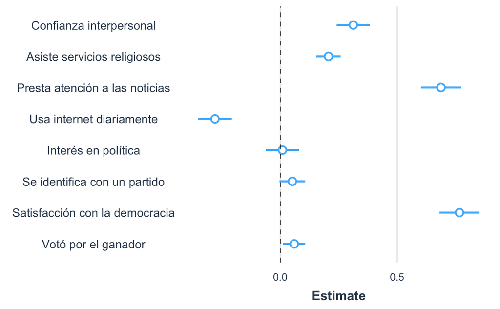

```r
plot_summs(modelo2, coefs=c("Confianza interpersonal" = "it1r",
                            "Asiste servicios religiosos" = "q5a01",
                            "Presta atención a las noticias" = "newsattn",
                            "Usa internet diariamente" = "useinternet",
                            "Interés en política" = "polinterest",
                            "Se identifica con un partido" = "idpty",
                            "Satisfacción con la democracia" = "satisdem",
                            "Votó por el ganador" = "votewinner"))
```

Tanto la confianza interpersonal y la asistencia a servicios religiosos son predictores significativos de un mayor nivel de confianza en los medios de comunicación. Un cambio de una respuesta según la cual las personas en la comunidad del entrevistado son “nada confiables” a una respuesta según la cual ellos son “muy confiables”, está asociada con un aumento de 0.3 puntos en la confianza en los medios de comunicación (en una escala de siete puntos). Un cambio de asistir “nunca o casi nunca” a los servicios religiosos a asistir al menos “una o dos veces al año” se estima que aumentaría la confianza en 0.2 puntos. Estos dos hallazgos respaldan la expectativa de que algunas personas, en general, tienen una mayor disposición a confiar que otras personas y que estas diferencias en la inclinación de las personas a confiar ayuda a explicar la variación individual en el nivel de confianza en los medios de comunicación. Coincidiendo con la expectativa de que las personas que no confían en los medios de comunicación tienen una menor probabilidad de consumirlos, las personas que prestan más atención a las noticias confían más en los medios de comunicación, en promedio, que las personas que le prestan menos atención. Un cambio desde “nunca” prestar atención a las noticias hasta hacerlo “a diario” está asociado con un aumento de 0.7 puntos en la confianza reportada en los medios de comunicación. Por el contrario, se encuentra que el uso del internet predice menores niveles de confianza en los medios de comunicación. Un cambio desde “nunca” usa internet a usarlo “a diario” está asociado con una caída de 0.3 puntos en la confianza reportada en los medios de comunicación. Aunque el uso personal de internet no refleja perfectamente el consumo de noticias en línea, una asociación negativa entre el consumo de internet y la confianza en los medios de comunicación es un indicio de una asociación negativa entre el consumo de noticias en línea y la confianza en los medios de comunicación. En sentido contrario a la expectativa de que las personas que están involucradas personalmente en un gran número de asuntos políticos podrían confiar menos en los medios de comunicación, ni el interés en política ni la identificación con un partido político parecen ser predictores significativos de la confianza en los medios de comunicación. El hallazgo de que el interés en la política no es un predictor significativo de la confianza en los medios de comunicación respalda investigaciones anteriores. El hallazgo de que la identificación con un partido no está asociada significativamente con la confianza en los medios de comunicación no respalda resultados pasados relacionados con una relación positiva entre la identificación con un partido y la percepción de que los medios de comunicación son sesgados43. Sin embargo, la evidencia de esta relación viene de trabajos que únicamente analizan encuestas realizadas en Estados Unidos. Por tanto, es posible que la relación esperada no ocurre consistentemente fuera de los Estados Unidos. También es posible que las percepciones de que existe un sesgo en contra de un partido político en particular aumentan en países que no sean de los Estados Unidos, pero ese aumento no es tan importante como para influir de forma notable en la confianza en los medios de comunicación. Las personas que reportan un mayor nivel de satisfacción con la democracia en su país reportan un mayor nivel de confianza en los medios de comunicación que las personas que están menos satisfechas. Un cambio de estar “muy insatisfecho” con la forma como la democracia está funcionando a estar “muy satisfecho” está asociado con un aumento de 0.8 en la confianza en los medios de comunicación. Este resultado respalda la posibilidad de que exista una relación positiva entre la confianza política y la confianza en los medios de comunicación. Por último, en promedio, las personas que reportaron votar por un candidato presidencial que resultó ganador en las últimas elecciones presidenciales también reportan un mayor nivel de confianza que las personas que no votaron por el candidato ganador46. Votar por el “ganador” más reciente está asociado con un aumento de 0.1 en la confianza en los medios de comunicación. Aunque pequeño, este resultado representa un apoyo modesto a la expectativa de que quienes respaldan a los “ganadores” confían en general más que los “perdedores”.